# Aerosol condensation process and its verification test: self-convergence rate of semi-implicit solutions of SOAG/SOA against different $\alpha_{_{astem}}$

### $\color{red}{\text{Last update: 07-29-2019, test strategy, result and presentation need revision.}}$

## 1 Introduction

Condensation represents the process that the vapor of a compound condenses onto the surface of existing particle population. MAM currently considers two trace gases: sulfur acid gas ($\rm H_2SO_4$, and its condensed particles $\rm SO_4$) and a single lumped gas species of secondary organic aerosol (SOAG, and its condensed particles SOA \cite{liu-2012-gmd}).

By assuming that the particles are spherical and the size distribution of the particle population is described by a few log-normal modes, the governing equations for the condensation of SOAG read:

\begin{align} C_{_{H_2SO_4,i}} &= \int_{-\infty}^{\infty} 2 \pi D_{_p} \mathbb{D}_{_{g,H_2SO_4}} f(K_{_{n,H_2SO_4}},\alpha_{_{H_2SO_4}}) n_{_{i}}(\ln D_{_{p}}) d\ln D_{_{p}} \,, \label{kmt-h2so4} \\ C_{_{SOAG,i}} &\approx 0.81C_{_{H_2SO_4,i}} \,, \label{kmt-soag} \\ \frac{dq_{_{v,SOAG}}}{dt} &= \sum_{i=1}^{I} C_{_{SOAG,i}} (q_{_{SOAG}}-q_{_{v,SOAG,sat,i}}) \,, \label{qgsoag} \\ \frac{dq_{_{m,SOA,i}}}{dt} &= C_{_{SOAG,i}} (q_{_{v,SOAG}}-q_{_{v,SOAG,sat,i}}) \,, i = 1,2,...,I \,, \label{qasoa} \end{align}

where the definitions of variables in Eq. \eqref{kmt-h2so4} can be found in a separate model documentation; $q_{_{v,SOAG}}$ is the mass mixing ratio of SOAG (unit: kmol of SOAG per kmol of dry air); $q_{_{m,SOA,i}}$ is the mass mixing ratio of SOA in mode $i$; $q_{_{v,SOAG,sat,i}}$ is the saturation vapor mixing ratio of SOAG for mode $i$, considering the existence of oxygenated primary organic aerosol (OPOA).

To solve for $q_{_{v,SOAG}}$ and $q_{_{m,SOA,i}}$, MAM assumes that $C_{_{SOAG,i}}$ are fixed within one time step $\Delta t_{_{cond}}$ ($\Delta t_{_{cond}} = t_{_1} - t_{_0}$). A semi-implicit method is then used to solve Eq. \eqref{qgsoag} and \eqref{qasoa}. More details about the basic notations, model parameterization, assumptions and numerical implementation can be found in a separate ''MAM_Basics'' and model documentation.

## 2 Goals

MAM implemented a dynamical substepping approach within one $\Delta t_{_{cond}}$ to solve for the semi-implicit solutions of SOAG/SOA. The varying-length substep $\Delta t_{_{SOAG}}$ is controlled by a user-specified error-control parameter $\alpha_{_{astem}}$ with smaller $\alpha_{_{astem}}$ leading to smaller $\Delta t_{_{SOAG}}$. In this test, we aim at examining whether the relative errors of solutions decrease linearly with the decrease of $\alpha_{_{astem}}$ in a log-log scale plot (e.g., $1^{st}$-order convergence rate). We would perform a self-convergence test of semi-implicit solutions of SOAG/SOA against different $\alpha_{_{astem}}$ to facilitate this purpose. Note that for this test, **$C_{_{SOAG,i}}$ are fixed over the whole simulation time** and we do not consider the existence of $\rm H_2SO_4/SO_4$ at this moment.

## 3 Steps to establish the verification test

This verification test uses a box model that inherits the data structure and condensation subroutines from MAM in E3SM. The box model serves as a driver program to specify the necessary parameters in order to calculate the MAM and reference solutions.

### 3.1 MAM solution

According to the mass conservation law, the molar mixing ratio of SOAG/SOA is conserved over any time interval during the condensation process. Thus we could define a constant $q_{_{tot}}$ as:

\begin{equation} q_{_{tot}} = q_{_{v,SOAG}}(t_{_0}) + \sum\limits_{i=1}^{I} q_{_{m,SOA,i}}(t_{_0}) \,. \end{equation}

The varying-length substep $\Delta t_{_{SOAG}}$ ($\Delta t_{_{SOAG}} \le \Delta t_{_{cond}}$, $\Delta t_{_{SOAG}} = t_{_{new}} - t_{_{old}}$, $t_{_0} \le t_{_{old}} \lt t_{_{new}} \le t_{_1}$) is first calculated by:

\begin{align} q_{_{v,SOAG,sat,i}} (t_{_{old}}) &= \frac{q_{_{m,SOA,i}}(t_{_{old}})}{\max \left( q_{_{m,OPOA,i}}(t_{_0}) + q_{_{m,SOA,i}}(t_{_{old}}), 10^{-20} \right)} q_{_{v,SOAG,equ}}(t_{_0}) \,, \\ \Phi_{_i} (t_{_{old}}) &= \frac{q_{_{v,SOAG}}(t_{_{old}}) - q_{_{v,SOAG,sat,i}}(t_{_{old}})}{\max \left( q_{_{v,SOAG}}(t_{_{old}}), q_{_{v,SOAG,sat,i}}(t_{_{old}}), 10^{-20} \right)} \,, \\ \Delta t_{_{SOAG}} &= \min \left( \frac{\alpha_{_{astem}}}{\sum\limits_{i=1}^{I} \left( C_{_{SOAG,i}}(t_{_0}) \left| \Phi_{_i}(t_{_{old}}) \right| \right)}, t_{_1} - t_{_{old}} \right) \,. \label{dtsub} \end{align}

The semi-implicit solutions of Eq. \eqref{qgsoag} and \eqref{qasoa} from $t_{_{old}}$ to $t_{_{new}}$ then read:

\begin{align} q_{_{v,SOAG}}(t_{_{new}}) &= \frac{q_{_{tot}} - \sum\limits_{i=1}^{I} \frac{q_{_{m,SOA,i}}(t_{_{old}})}{\chi_{_i}^*}} {1 + \sum\limits_{i=1}^{I} \frac{\psi_{_i}^*}{\chi_{_i}^*}} \,, \label{sol-soag} \\ q_{_{m,SOA,i}}(t_{_{new}}) &= \frac{q_{_{m,SOA,i}}(t_{_{old}}) + \psi_{_i}^* q_{_{v,SOAG}}(t_{_{new}})}{\chi_{_i}^*} \,, \label{sol-soa} \end{align}

where $\psi_{_i}^* = C_{_{SOAG,i}} (t_{_0}) \Delta t_{_{SOAG}}$, $\chi_{_i}^* = 1 + \psi_{_i}^* \theta_{_i}^*$ and $\theta_{_i}^* = \frac{q_{_{v,SOAG,equ}} (t_{_0})}{\max \left( q_{_{m,SOA,i}}^*+q_{_{m,OPOA,i}} (t_{_0}), \, 10^{-20} \right)}$. $q_{_{v,SOAG,equ}}(t_{_0})$ is the saturation vapor mixing ratio of SOAG without considering the existence of OPOA. After a few sub-steps, $t_{_{new}} = t_{_1}$ and MAM solves for the solutions of SOAG/SOA after one $\Delta t_{_{cond}}$. More details can be found in a separate model documentation.

In this test, the MAM solutions of SOAG/SOA are generated using the same $\Delta t_{_{cond}}$ but different $\alpha_{_{astem}}$ ranging from $10^{-4}$ to 1. The default value of $\alpha_{_{astem}}$ is 0.05 in MAM.

### 3.2 Reference solution

The reference solution is generated by the same method mentioned in Section 3.1 but with $\alpha_{_{astem}} = 10^{-5}$.

### 3.3 Parameters required for this verification test

To perform this verification test, the following quantities are specified: %

\begin{enumerate} \item All the parameters used to calculate the $C_{_{H_2SO_4,i}}$. These include: \begin{itemize} \item Accommodation coefficient $\alpha_{_{H_2SO_4}} = 0.65$ (unitless, \cite{poschl-1998-jpca}). \item Temperature $T$, for which we use 273 K as an example. \item Pressure $P$, for which we use 1000 hPa as an exmaple. \item Molecular diffusion volume (unitless) $\mathbb{V}_{_{D,H_2SO_4}} = 42.88$ and $\mathbb{V}_{_{D,air}} = 20.1$. \item Molecular weight $M_{_{w,H_2SO_4}} = 98.0783997$ and $M_{_{w,air}} = 28.966$. \item Number concentration of particle population in mode $i$ ($N_{_{t,i}}$, unit: $\# \cdot m^{-3}$). We set the typical numbers in reality. \begin{equation} N_{_{t,1}} = 10^8, N_{_{t,2}} = 10^9, N_{_{t,3}} = 10^5, N_{_{t,4}} = 2 \times 10^8. \nonumber \end{equation} \item Geometric mean dry diameter ($D_{_{gn,d,i}}$) and geometric standard deviation ($\sigma_{_{g,i}}$) for each mode. The values of $D_{_{gn,d,i}}$ and $\sigma_{_{g,i}}$ are chosen to represent the midrange values for tropospheric aerosol observations \cite{dick-2004-jgr, liu-2012-gmd}, and are listed in the ''MAM_Basics'' documentation. The geometric mean wet diameter ($D_{_{gn,w,i}}$) is the actual value used to calculate the $C_{_{l,i}}$ and is assumed to be 1.2 times $D_{_{gn,d,i}}$ for simplicity. \item Gauss-Hermite quadrature points and their associated weights. For this test, both MAM and reference solutions use 2 Gauss-Hermite quadrature points. They are generated using the Python function **numpy.polynomial.hermite.hermgauss** with 16 decimal digits \cite{Python-ghq}. \end{itemize} With $C_{_{H_2SO_4,i}}$ known, $C_{_{SOAG,i}}$ is then approximated by Eq. \eqref{kmt-soag}. \item Simulation length $\Delta t_{_{tot}}$, which is set to 1800 seconds. \item Time step $\Delta t_{_{cond}}$, which is set to 1800 seconds. \item Error-control paramerter $\alpha_{_{astem}}$ (unitless). In this test, we use the following values to generate the MAM solutions: \begin{equation} \alpha_{_{astem}} \in [1.,0.1,0.05,0.01,10^{-3},10^{-4}] \nonumber \end{equation} We use $\alpha_{_{astem}} = 10^{-5}$ to generate the reference solution. \item Density (unit: $\rm kg \cdot m^{-3}$) and molecular weight (unit: $\rm g \cdot mol^{-1}$) of aerosol species ($\rho_{_{l}}$ and $M_{_{w,l}}$), for which the following values are used: $$[\rho_{_{SO_4}}:1770 \ ; \rho_{_{POA}}:1000 \ ; \rho_{_{SOA}}:1000 \ ; \rho_{_{BC}}:1700 \ ; \rho_{_{SS}}:1900 \ ; \rho_{_{DST}}:2600 \ ; \rho_{_{MOA}}:1601] \,, \nonumber$$ $$[M_{_{w,SO_4}}:115 \ ; M_{_{w,POA}}:12 \ ; M_{_{w,SOA}}:12 \ ; M_{_{w,BC}}:12 \ ; M_{_{w,SS}}:58.5 \ ; M_{_{w,DST}}:135 \ ; M_{_{w,MOA}}:250092] \,. \nonumber$$ \item Initial mass fractions of aerosol species in mode $i$ ($f_{_{m,l,i}}$), whose values are shown below (numbers in the parentheses) as the example setting. \begin{align} \text{ Accumulation}:& &\text{SS(50%)},& &\text{SOA(50%)}, \nonumber \\ \text{ Aitken}:& &\text{SS(50%)},& &\text{SOA(50%)}, \nonumber \\ \text{ Coarse}:& &\text{DST(50%)},& &\text{SOA(50%)}, \nonumber \\ \text{Primary carbon}:& &\text{POA(50%)},& &\text{BC(50%)}. \nonumber \end{align} No initial SOA and $\rm SO_4$ are specified for the primary carbon mode because that mode only contains BC, POA and MOA. By specifying the $T$, $p$, $R$, $N_{_{t,i}}$, $D_{_{gn,d,i}}$, $\sigma_{_{g,i,}}$, $\rho_{_{l}}$, $M_{_{w,l}}$ and $f_{_{m,l,i}}$, we could then calculate the initial $q_{_{m,l,i}}$ as: \begin{equation} q_{_{m,l,i}} = \frac{\frac{\pi}{6} N_{_{t,i}} D_{_{gn,d,i}}^3 \exp \left( \frac{9}{2} \ln^2 \sigma_{_{g,i}} \right)} {\sum\limits_{l}\frac{f_{_{m,l,i}}}{\rho_{_{l}}}} \cdot f_{_{m,l,i}} \cdot \frac{\rho_{_{l}}RT}{1000 M_{_{w,l}} p} \,. \end{equation} \item Initial mass mixing ratio of $q_{_{v,SOAG}}$, which is set to $5 \times 10^{-10}$, close to the global mean value at the surface layer. \end{enumerate}

With these parameters given, totally 5 (= 4 (modes for aerosols + 1 (gas species)) verification tests are performed.

### 3.4 PASS/FAIL criterion

We first calculate the MAM solutions with different $\alpha_{_{astem}}$ based on Eq. \eqref{sol-soag} and \eqref{sol-soa} (denoted as $q_{_{v,MAM}}$ and $q_{_{m,MAM,i}}$). We then calculate the reference solution with $\alpha_{_{astem}} = 10^{-5}$ (denoted as $q_{_{v,REF}}$ and $q_{_{m,REF,i}}$). Thus the relative error $\phi$ can be calcualted by:

\begin{align} \phi_{_v} &= \frac{\left| q_{_{v,MAM}} - q_{_{v,REF}} \right|}{q_{_{v,REF}}} \,, \\ \phi_{_{m,i}} &= \frac{\left| q_{_{m,MAM,i}} - q_{_{m,REF,i}} \right|}{q_{_{m,REF,i}}} \,. \end{align}

A self-convergence test is performed by plotting $\phi$ against $\alpha_{_{astem}}$ on a log-log scale figure. We further fit a line to the pairs of ($\alpha_{_{astem}}$, $\phi$) where $\alpha_{_{astem}} \le 0.05$.

An overall **PASS** is issued if the slope of fitted line is 1.0$\pm \delta$ for both $\phi_{_v}$ and $\phi_{_{m,i}}$ (Here $\delta$ is a user-specified parameter so that 1.0$\pm \delta$ is thought close enough to 1.0).

## 4 Source codes and configuration files of verification test

The verification test requires a test driver to perform the verification test and the configuration files for compilation and execution of **cmdv-test-runner** (e.g., the yaml file). If we go the root directory of **CMDV-Verification** folder that is cloned from GitHub Repo, the test driver code (**driver.F90**) is under $\rm \color{blue}{tests/mam/restructed\_tests/F90\_SRC/test\_drivers/condensation/soag\_substep\_convergence}$ and the yaml file is under $\rm \color{blue}{tests/mam/restructed\_tests/yaml\_files\_for\_test\_runner/condensation/soag\_substep\_convergence.test.yaml}$.

## 5 Verification Results

If the verification test runs successfully, we should obtain the netcdf file named **"condensation_verification_test.nc"** with the MAM and reference solutions for $q_{_{v,SOAG}}$ and $q_{_{m,SOA,i}}$. Assuming that the netcdf file is put under the **"postprocess_input"** folder, the following cells would calculate the relative errors $\phi$, perform a self-convergence test of MAM solutions and check whether a **PASS/FAIL** should be issued. Note that the asterisk symbol in the figures below means the relative error using the default $\alpha_{_{astem}} = 0.05$ in MAM.

```python
# load the library
import numpy as np
import xarray as xr
import postprocess_scripts.plot_conden_convergence as ps
```

```python
# define the file path and name
nc_file   = "./postprocess_input/condensation_verification_test.nc"
outpath   = "./postprocess_output/"
```

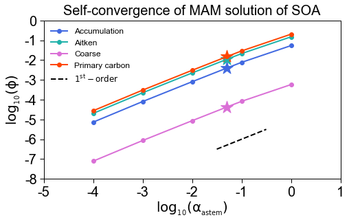

```python
# make the self-convergence plot of MAM solution for SOA
ps.plot_convergence(nc_file, outpath, var_type='aer', porder=[1],
                    xlabel=np.arange(-5,2,1), ylabel=np.arange(-8,4,1), xlim=[-5,1], ylim=[-8,0],
                    left=0.1, right=1.1, top=0.9, bottom=0.1, hspace=0, wspace=0.1,
                    nrows=1, ncols=1, fontheight=20)
```

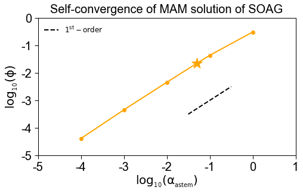

```python
# make the self-convergence plot of MAM solution for SOAG
ps.plot_convergence(nc_file, outpath, var_type='gas', porder=[1],
                    xlabel=np.arange(-5,2,1), ylabel=np.arange(-6,2,1), xlim=[-5,1], ylim=[-5,0],
                    left=0.1, right=1.1, top=0.9, bottom=0.1, hspace=0, wspace=0.1,
                    nrows=1, ncols=1, fontheight=20, loc='upper left')
```

If a user uses the same settings in Section 3.3 and does not change the source codes, the self-convergence results of SOAG/SOA would look like:

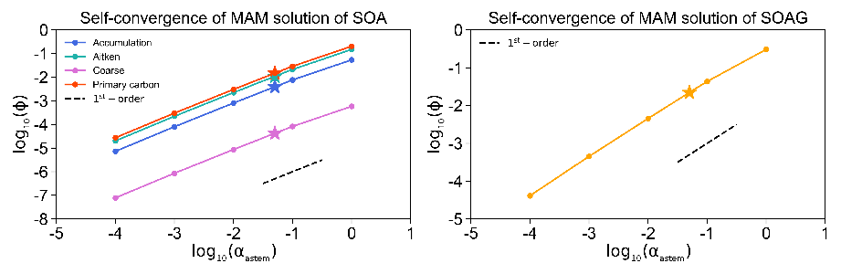

```python
# trusted output for SOAG/SOA
ps.show_figures('./trusted_output/', left=0.1, right=2.2, top=2.2, bottom=0.1, hspace=0, wspace=0)
```

Based on the plots of self-convergence test for SOAG/SOA above, we further fit a line to the pairs of ($\alpha_{_{astem}}$, $\phi$) where $\alpha_{_{astem}} \le 0.05$. The resulted slope of fitted line is:

```python
# show the slope of fitted line
slope_gas, slope_aer = ps.calc_slope(nc_file)
```

```
slope of fitted line for SOAG:          1.01121
slope of fitted line for SOA in mode 1: 1.01123
slope of fitted line for SOA in mode 2: 1.01121
slope of fitted line for SOA in mode 3: 1.01124
slope of fitted line for SOA in mode 4: 1.01116
```

With the slopes known, we could then check whether a **PASS/FAIL** should be issued. Here we set $\delta = 0.02$ as a threshold (meaning the verification test passes if and only if the fitted slopes are all within 1$\pm$0.02 ).

```python
# run this cell to issue PASS/FAIL
ps.issue_flag(nc_file, slope_gas, slope_aer, delta=0.02)
```

```
PASS
```

# References

[1] Liu X., Easter R. C., Ghan S. J. *et al.*, ``*Toward a minimal representation of aerosols in climate models: description and evaluation in the Community Atmosphere Model CAM5*'', Geoscientific Model Development, vol. 5, number 3, pp. 709--739, 2012. [online](https://www.geosci-model-dev.net/5/709/2012/)

[2] P{\"o}schl Ulrich, Canagaratna Manjula, Jayne John T *et al.*, ``*Mass accommodation coefficient of H2SO4 vapor on aqueous sulfuric acid surfaces and gaseous diffusion coefficient of H2SO4 in N2/H2O*'', The Journal of Physical Chemistry A, vol. 102, number 49, pp. 10082--10089, 1998.

[3] Easter Richard C., Ghan Steven J., Zhang Yang *et al.*, ``*MIRAGE: Model description and evaluation of aerosols and trace gases*'', Journal of Geophysical Research: Atmospheres, vol. 109, number D20, pp. , 2004.

[4] Daniel Zwillinger, ``*CRC standard mathematical tables and formulae*'', 2002.

[5] , ``*Python function to generate the Gauss–Hermite quadrature points*'', . [online](https://docs.scipy.org/doc/numpy-1.13.0/reference/generated/numpy.polynomial.hermite.hermgauss.html#numpy.polynomial.hermite.hermgauss)